# Analysis of Which American Weather Events Cause the Most Damages to Human Life and Private Property, 1950 - 2011

Bryan Murphy

2023-04-04

```r
library(tidyverse)
library(R.utils)
library(lubridate)
library(forcats)
library(stringdist)
```

```r
# This is our initial setup block, named setup, with include = TRUE so it will show up.

# First we'll set any global variables we care about...
options(scipen=999) # This stops knitr from displaying 5 digit numbers as Scientific Notation.
options(cache = TRUE)
# And then we'll use a seperate code chunk to load our data.
```

```r
#Here we download our dataset, if it's not already downloaded, and read it as a tibble into RStudio.

fileUrl <- "https://d396qusza40orc.cloudfront.net/repdata%2Fdata%2FStormData.csv.bz2" # Set the DL link url.

if(!file.exists("./Proj2data/Stormdata.csv.bs2")) {download.file(fileUrl,destfile="./Proj2data/StormData.csv.bz2",method="curl")} # Actually download the file.

gunzip(filename = "./Proj2data/StormData.csv.bz2", destname = "./Proj2data/StormData.csv",
       skip = TRUE, ext = "bz2")
```

```
## [1] "./Proj2data/StormData.csv"
## attr(,"temporary")
## [1] FALSE
```

```r
stormdata <- as_tibble(read.csv(file = "./Proj2data/StormData.csv", stringsAsFactors = FALSE, strip.white = TRUE))
```

# **Part 1: Synopsis**

Adverse weather events are a significant cause of damage to human health as well as private and public property in the United States. This report analyzes the effects of weather events on the United States, with a focus on the health and economic consequences of adverse weather. The data used in this analysis is derived from the U.S. National Oceanic and Atmospheric Administration’s (NOAA) storm database from the years 1950 to 2011.

This report concludes that adverse weather events have significant health and economic consequences in the United States, but that the weather patterns which cause the most damage to human life are not the same as those which cause the most damage to property. In particular, Tornadoes, Heat and Lightning cause the most human injuries and fatalities, while in general, water-related weather events, particularly Floods and Hurricanes/Typhoons, cause by far the most economic damage to the United States. Tornadoes, however,despite not being dependent on water, tend to cause a great deal of damage to both private property as well as human lives.

This report concludes by noting that further study is necessary, and that it would be particularly worthwhile expanding the analysis to the present day. For example, it is highly probable heat-related weather events have been more consequential in the last decade, with wildfires becoming more common as global climate change leads to drier weather in some U.S. states, particularly California.

# **Part 2: Data Processing and Cleaning**

After loading our data, we look at some general descriptive statistics of the data set. We see it has $902,297$ observations across $37$ variables. Converting the data in the column named BGN_DATE to a format readable by R as an actual date and not a character string, we can then also see that the data begins on Jan. 3rd, 1950, and ends on Nov. 30th, 2011.

```r
stormdata$BGN_DATE <- mdy_hms(stormdata$BGN_DATE)

stormdata$BGN_DATE <- as.Date(stormdata$BGN_DATE)

range(stormdata$BGN_DATE)
```

```
## [1] "1950-01-03" "2011-11-30"
```

Out of curiosity, we decide to look up the most fatal weather incident in this dataset. A quick subsetting of the dataset by the row which has the maximum number of fatalities tells us that the event with the most fatalities recorded in this dataset is the 1995 Chicago heatwave, with $583$ deaths. While a tragedy, this dataset covers the year in which Hurricane Katarina happens, which should handily exceed the death toll of the 1995 Chicago Heatwave.

```r
maxfatal <- stormdata[stormdata$FATALITIES == max(stormdata$FATALITIES), ]
glimpse(maxfatal[c(2,7,8,23)])
```

```
## Rows: 1
## Columns: 4
## $ BGN_DATE   <date> 1995-07-12
## $ STATE      <chr> "IL"
## $ EVTYPE     <chr> "HEAT"
## $ FATALITIES <dbl> 583
```

However, a quick look at the Hurricane Katarina data shows us that the incident is set to $0$ fatalities, while Katrina’s own *REMARKS* column indicates the event caused $1097$ fatalities!

```r
stormdata[stormdata$REFNUM == 577615,23]
```

```
## # A tibble: 1 × 1
##   FATALITIES
##        <dbl>
## 1          0
```

```r
Katrina <- stormdata[stormdata$REFNUM == 577615,]

Katrina$REMARKS
```

```
## [1] "Hurricane Katrina was one of the strongest and most destructive hurricanes on record to impact the coast of the United States.  It will likely be recorded as one the worst natural disaster in the history of the United States to date resulting in catastrophic damage and numerous casualties in…
```

This is a baffling omission, so we’ll fix that.

There might be other errors in the dataset, but it seemed very relevant to this analysis to ensure that the single most fatal weather event in the time period that dataset comprises was recorded accurately.

```r
stormdata[stormdata$REFNUM == 577615,23] <- 1097
max(stormdata$FATALITIES)
```

```
## [1] 1097
```

That accomplished, we can now begin to look at the dataset to answer the following two questions:

> **1: Across the United States, which types of events kill and injure the most people??**

> **2: Across the United States, which types of events have the greatest economic consequences?**

In order to look at these questions in more detail, and to avoid the unwieldyness of dealing with an enormous dataset, we are going to subset our initial data, named *stormdata*, into two smaller datasets, *human_events*, comprising only those weather-related incidents which resulted in at least $1$ human injury and/or fatality, and *property_events*, comprising only those weather-related incidents which resulted in some measurable damage to property (including crop damage from 1993 onward).

```r
human_events <- filter(stormdata, FATALITIES > 0 | INJURIES > 0)
property_events <- filter(stormdata, PROPDMG > 0 | CROPDMG > 0)

crops <- filter(property_events, CROPDMG > 0)

range(crops$BGN_DATE)
```

```
## [1] "1993-01-04" "2011-11-28"
```

# **Results**

### **Weather Events Impacting Human Health**

We’ll start by focusing on weather events in the United States from 1950 until 2011 that had a direct impact on human health - in other words, the data contained within our subset *human_events*.

Before we go any further, we are going to want to try to group *human_events* by the column *EVTYPE*, so we can try and look at the cumulative effect on human health for specific types of weather incidents.

```r
human_events %>%  group_by(EVTYPE) %>%
      summarise(FATALITIES = sum(FATALITIES), INJURIES = sum(INJURIES))%>%
      arrange(desc(FATALITIES + INJURIES)) -> summed_human_events
```

However, when we do this, we notice our dataset covers *$220$* different supposed event types. This is a lot less than the apparently *$985$* different type of weather events in the original data set, but according to [the NOAA itself](https://www.ncdc.noaa.gov/stormevents/details.jsp), the **Storm Events Database** should only include $48$ different types of weather events! Looking at the column *EVTYPE* manually, we notice the reason there are $985$ event types instead of $48$ is… a massive number of typos collected over the course of over $50$ years of data entry, much of which was probably done manually for decades.

```r
length(unique(summed_human_events$EVTYPE))
```

```
## [1] 220
```

```r
length(unique(stormdata$EVTYPE))
```

```
## [1] 985
```

```r
head(unique(stormdata$EVTYPE),40)
```

```
##  [1] "TORNADO"                        "TSTM WIND"
##  [3] "HAIL"                           "FREEZING RAIN"
##  [5] "SNOW"                           "ICE STORM/FLASH FLOOD"
##  [7] "SNOW/ICE"                       "WINTER STORM"
##  [9] "HURRICANE OPAL/HIGH WINDS"      "THUNDERSTORM WINDS"
## [11] "RECORD COLD"                    "HURRICANE ERIN"
## [13] "HURRICANE OPAL"                 "HEAVY RAIN"
## [15] "LIGHTNING"                      "THUNDERSTORM WIND"
## [17] "DENSE FOG"                      "RIP CURRENT"
## [19] "THUNDERSTORM WINS"              "FLASH FLOOD"
## [21] "FLASH FLOODING"                 "HIGH WINDS"
## [23] "FUNNEL CLOUD"                   "TORNADO F0"
## [25] "THUNDERSTORM WINDS LIGHTNING"   "THUNDERSTORM WINDS/HAIL"
## [27] "HEAT"                           "WIND"
## [29] "LIGHTING"                       "HEAVY RAINS"
## [31] "LIGHTNING AND HEAVY RAIN"       "FUNNEL"
## [33] "WALL CLOUD"                     "FLOODING"
## [35] "THUNDERSTORM WINDS HAIL"        "FLOOD"
## [37] "COLD"                           "HEAVY RAIN/LIGHTNING"
## [39] "FLASH FLOODING/THUNDERSTORM WI" "WALL CLOUD/FUNNEL CLOUD"
```

For example, in only the $40$ entries above, we see **THUNDERSTORM WINDS** written as everything from **THUNDERSTORM WINDS** to **THUNDERSTORM WINS** to **TSTM WIND**, all of which are currently considered separate event types, even though they obviously are not.

Before we start, we’re also going to correct two particularly problematically misentered event type observations - one event type was listed as “cold” when the official weather formatting should be **“Extreme Cold/Wind Chill”**, which will cause that observation to be mismatched as “flood” simply because flood has the letters O,L and D and is a short word, and one observation is listed as the unnecessarily loquacious “unseasonably warm and dry,” which we’ll amend to the official event type, **“Heat”**.

Having corrected these outliers, we’ll create a vector, *dictionary*, of the NOAA’s $48$ official storm event types, and then use approximate string matching using the amatch() command to condense all of the $220$ event types we currently have into the official $48$.We are going to use the **longest common substring** method, as this will help ensure events like “Ex. Cold” get matched to the event type “Extreme Cold/Wind Chill” even though the difference in the number of characters is fairly large, rather than to something like “Funnel Cloud” or “Flood”, which is closer in character count to “Ex. Cold” but don’t even contain the word “cold”.

```r
summed_human_events[47,1] <- "extreme cold"
summed_human_events[67,1] <- "heat"

dictionary <- c("Astronomical Low Tide","Avalanche","Blizzard","Coastal Flood","Cold/Wind Chill","Debris Flow","Dense Fog","Dense Smoke","Drought","Dust Devil","Dust Storm","Excessive Heat","Extreme Cold/Wind Chill","Flash Flood","Flood","Freezing Fog","Frost/Freeze","Funnel Cloud","Hail","Heat","Heavy Rain","Heavy Snow","High Surf","High Wind","Hurricane","Typhoon","Ice Storm","Lakeshore Flood","Lake-Effect Snow","Lightning","Marine Hail","Marine High Wind","Marine Strong Wind","Marine Thunderstorm Wind","Rip Current","Sleet","Storm Tide","Strong Wind","Thunderstorm Wind","Tornado","Tropical Depression","Tropical Storm","Tsunami","Volcanic Ash","Waterspout","Wildfire","Winter Storm","Winter Weather")

dictionary <- tolower(dictionary)

summed_human_events$EVTYPE <- tolower(summed_human_events$EVTYPE)


summed_human_events$EVTYPE_MATCHED <- dictionary[amatch(summed_human_events$EVTYPE,dictionary,method="lcs", maxDist=40)]

length(unique(summed_human_events$EVTYPE_MATCHED))
```

```
## [1] 41
```

You can see we’re now down to just $41$ event types (because $7$ of the official $48$ event types never actually caused any human injuries or fatalities). Now we can look at just the top $10$ entries in our refined dataset *summed_human_events* to see the $10$ storm types in the United States from 1950 to 2011 which caused the most human injuries and fatalities.(We’ll also delete the column containing the $220$ unmatched event types)

```r
summed_human_events$EVTYPE <- NULL
head(summed_human_events,10) -> human10
human10
```

```
## # A tibble: 10 × 3
##    FATALITIES INJURIES EVTYPE_MATCHED
##         <dbl>    <dbl> <chr>
##  1       5633    91346 tornado
##  2       1903     6525 excessive heat
##  3        504     6957 strong wind
##  4        470     6789 flood
##  5        816     5230 lightning
##  6        937     2100 heat
##  7        978     1777 flash flood
##  8       1161     1275 hurricane
##  9         89     1975 ice storm
## 10        133     1488 thunderstorm wind
```

Before we do anything else, we’re going to recapitalize our event types, as we put them all into lower case for the sake of making our approximate matching work better.

```r
capwords <- function(s, strict = FALSE) {
      cap <- function(s) paste(toupper(substring(s, 1, 1)),
                               {s <- substring(s, 2); if(strict) tolower(s) else s},
                               sep = "", collapse = " " )
      sapply(strsplit(s, split = " "), cap, USE.NAMES = !is.null(names(s)))
}

summed_human_events$EVTYPE_MATCHED <- capwords(summed_human_events$EVTYPE_MATCHED)
head(summed_human_events,10) -> human10
```

Now we can try actually plotting the $10$ events which are most destructive to human life in the United States.

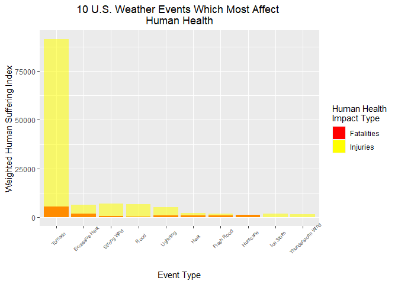

```r
ggplot(data = human10) +
      geom_col(mapping = aes(x = fct_reorder(EVTYPE_MATCHED, FATALITIES + INJURIES, .desc = TRUE), y = FATALITIES, fill = "Fatalities")) +
      geom_col(mapping = aes(x = fct_reorder(EVTYPE_MATCHED, FATALITIES + INJURIES, .desc = TRUE), y = INJURIES, fill = "Injuries", alpha = 0.5), show.legend = FALSE) +
      scale_fill_manual(values = c("Fatalities" = "red", "Injuries" = "yellow")) +
      theme(plot.title = element_text(hjust = 0.5), plot.caption = element_text(hjust = 0.5))+
      theme(axis.text.x = element_text(angle = 45, size = 6, margin = margin(10)))+
      labs(x = "Event Type", y = "Weighted Human Suffering Index", title = "10 U.S. Weather Events Which Most Affect \nHuman Health", fill = "Human Health \nImpact Type")
```

It hardly seems fair to weight Fatalities and Injuries equally, so we can create what we might call a *“Weighted Index of Human Suffering”* by assigning injuries a weight of $1$ and Fatalities a higher weight. As far as I know, most of the literature on the topic of determining an equivalency ratio between injury and death presumes you know the actual nature of the injury, i.e. for the sake of calculating the actuarial payout for an insurance claim,but since the NOAA doesn’t track that data, we can assign Fatality a generic weight of $10$, ensuring that a fatality is considered one order of magnitude more important than an injury.

Now, if we plot our data again, we see the following:

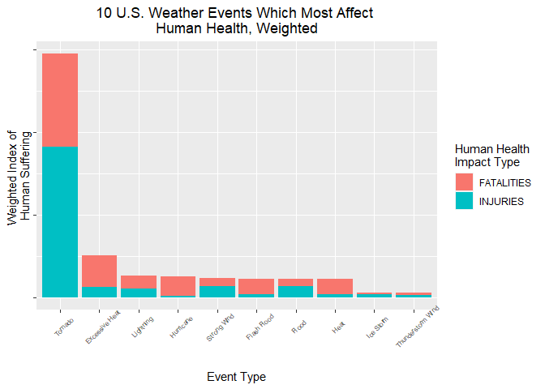

```r
human10_adj <- human10

human10_adj$FATALITIES <- human10$FATALITIES*10


human10_long_adj <- human10_adj %>%
      pivot_longer (cols = c(INJURIES, FATALITIES), names_to = "type", values_to = "value")

ggplot(data = human10_long_adj) +
      geom_col (mapping = aes (x = fct_reorder(EVTYPE_MATCHED, value, .desc = TRUE), y = value, fill = type)) +
      theme(plot.title = element_text (hjust = 0.5), plot.caption = element_text (hjust = 0.5))+
      theme(axis.text.x = element_text(angle = 45, size = 6, margin = margin(10))) +
      labs(x = "Event Type", y = "Weighted Index of \nHuman Suffering", title = "10 U.S. Weather Events Which Most Affect \nHuman Health, Weighted", fill = "Human Health \nImpact Type") +
      theme(axis.text.y = element_blank())
```

Now we see that while Tornado still leads the pack (being a storm type that tends to cause a fair number of fatalities, even though it causes far more injuries), we see that Hurricane jumps from $8th$ to a more plausible $4th$ place, Lightning and Strong Wind swapped places, with Lightning now being ranked higher, and Flash Flood is now ranked higher than Flood. All these changes make intuitive sense; for example, naturally more people would die in an unexpected flood than an expected one. This gives us reassurance that our weighting system was a good, if rudimentary idea.

In conclusion, we can see that in the United States from 1950 to 2011, the weather events which most impacted human health were Tornadoes, Heat waves, Lightning storms (probably correlated somewhat with tornadoes), and then Hurricanes, Strong Winds and Flash Floods. Ice Storms, as annoying as they might be to drivers in northern states, tend not to cause many fatalities, as well as comparatively few injuries compared to the higher ranked event types.

One final thing to note is that splitting up Excessive Heat from Heat seems to end up undercounting the effects of both events, but the NOAA itself explicitly draws this distinction, so we maintained it in our analysis.

### **Weather Events with Economic Consequences**

From here, we can go on to analyze weather events with economic consequences, defined as those weather events in the NOAA Storm Data set which contained an explicitly recorded value for either the variable PROPDMG or CROPDMG. PROPDMG is typically defined as damage inflicted to private property as well as public infrastructure and facilities; beginning in 1993, the NOAA began including estimates of damage to crops as well, hence the inclusion of the variable CROPDMG.

A quick calculation shows us that there are actually $5,857$ observations spanning the full duration of the period in which CROPDMG was being recorded that caused no property damage but some crop damage, which seems to imply the value of this variable; it’s uncertain whether these instances would simply have been rolled into property damage prior to 1993, however.

```r
stormdata %>%
      filter(CROPDMG > 0 & PROPDMG == 0) -> cropsonly
nrow(cropsonly)
```

```
## [1] 5857
```

```r
range(cropsonly$BGN_DATE)
```

```
## [1] "1993-01-19" "2011-11-27"
```

*Calculating dollar values for PROPDMG and CROPDMG*

One quirk of the NOAA dataset we have is that the values for property and crop damage are recorded as relatively short numbers, with the unit of measurement of that number recorded in a seperate column called PROPDMGEXP and CROPDMGEXP. Thus, an event that causes $25$ *thousand* dollars worth of damage to property would have the same PROPDMG value ($25$) as an event that caused $25$ *billion* dollars worth of damage to property. However, for the first event, the PROPDMGEXP would be “K” for thousand, while for the second it would be “B” for billion. (The dataset also includes “M” for million.)

Before proceeding further in our analysis, it would help to create variables called *PROPDMG_TOTAL* and *CROPDMG_TOTAL* by actually multiplying those PROPDMG values by the appropriate number ($1$ thousand, $1$ million or $1$ billion). We can then create a final value for each observation called TOTALDMG by summing PROPDMG_TOTAL and CROPDMG_TOTAL.

We have accomplished this neatly and quickly using case_when() from the *dplyr* package, as seen below.

```r
property_events$PROPDMG_TOTAL <- case_when (
      property_events$PROPDMGEXP == "K" ~ property_events$PROPDMG * 10^3,
      property_events$PROPDMGEXP == "M" ~ property_events$PROPDMG * 10^6,
      property_events$PROPDMGEXP == "B" ~ property_events$PROPDMG * 10^9,
      TRUE ~ 0
)

property_events$CROPDMG_TOTAL <- case_when (
      property_events$CROPDMGEXP == "K" ~ property_events$CROPDMG * 10^3,
      property_events$CROPDMGEXP == "M" ~ property_events$CROPDMG * 10^6,
      property_events$CROPDMGEXP == "B" ~ property_events$CROPDMG * 10^9,
      TRUE ~ 0
)

property_events$TOTALDMG <- (property_events$PROPDMG_TOTAL + property_events$CROPDMG_TOTAL)
```

This accomplished, we now group by EVTYPE again so we can see the cumulative economic consequences of particular weather events.

```r
property_events %>%  group_by(EVTYPE) %>%
      summarise(TotalDamage = sum(TOTALDMG)) %>%
      arrange(desc(TotalDamage)) -> summed_property_events

length(unique(summed_property_events$EVTYPE))
```

```
## [1] 431
```

Unfortunately, we see we have $431$ event types within our newly grouped subset, when really we want at most $48$. We follow the same approximate matching procedure as we did when looking at weather events impacting human health. Before we begin, we are going to split “Hurricane/Typhoon” into three entries in our dictionary, “Hurricane” “Typhoon” and “Hurricane/Typhoon”, and will re-collate these after the matching is done; this is done as including only “Hurricane/Typhoon” in our dictionary can sometimes cause events listed as “Hurricane” or “Typhoon” only to be matched to another category, which we don’t want.

We will also re-capitalize our Event Type names again, and delete the now unnecessary EVTYPE column.

```r
dictionary <- c("Astronomical Low Tide","Avalanche","Blizzard","Coastal Flood","Cold/Wind Chill","Debris Flow","Dense Fog","Dense Smoke","Drought","Dust Devil","Dust Storm","Excessive Heat","Extreme Cold/Wind Chill","Flash Flood","Flood","Freezing Fog","Frost/Freeze","Funnel Cloud","Hail","Heat","Heavy Rain","Heavy Snow","High Surf","High Wind","Hurricane","Typhoon","Hurricane/Typhoon","Ice Storm","Lakeshore Flood","Lake-Effect Snow","Lightning","Marine Hail","Marine High Wind","Marine Strong Wind","Marine Thunderstorm Wind","Rip Current","Sleet","Storm Tide","Strong Wind","Thunderstorm Wind","Tornado","Tropical Depression","Tropical Storm","Tsunami","Volcanic Ash","Waterspout","Wildfire","Winter Storm","Winter Weather")

dictionary <- tolower(dictionary)
summed_property_events$EVTYPE <- tolower(summed_property_events$EVTYPE)
summed_property_events$EVTYPE_MATCHED <- dictionary[amatch(summed_property_events$EVTYPE,dictionary,method="lcs", maxDist=60)]

summed_property_events$EVTYPE_MATCHED <- case_when(
      summed_property_events$EVTYPE_MATCHED == "hurricane" ~ "Hurricane/Typhoon",
      summed_property_events$EVTYPE_MATCHED == "hurricane/typhoon" ~ "Hurricane/Typhoon",
      summed_property_events$EVTYPE_MATCHED == "typhoon" ~ "Hurricane/Typhoon",
      TRUE ~ summed_property_events$EVTYPE_MATCHED
      )

summed_property_events$EVTYPE_MATCHED <- capwords(summed_property_events$EVTYPE_MATCHED)

summed_property_events$EVTYPE <- NULL

head(summed_property_events, 10)
```

```
## # A tibble: 10 × 2
##     TotalDamage EVTYPE_MATCHED
##           <dbl> <chr>
##  1 150319678250 Flood
##  2  71913712800 Hurricane/Typhoon
##  3  57340613590 Tornado
##  4  43323541000 Storm Tide
##  5  18752904170 Hail
##  6  17562128610 Flash Flood
##  7  15018672000 Drought
##  8  14610229010 Hurricane/Typhoon
##  9  10148404500 Flood
## 10   8967041310 Ice Storm
```

Looking at our $10$ most economically consequential weather events, we notice that we need to re-collate the data so all the various Hurricane/Typhoon observations get grouped back together, which we do below.

```r
summed_property_events %>%  group_by(EVTYPE_MATCHED) %>%
      summarise(TotalDamage = sum(TotalDamage)) %>%
      arrange(desc(TotalDamage)) -> summed_property_events_refined
head(summed_property_events_refined,10)
```

```
## # A tibble: 10 × 2
##    EVTYPE_MATCHED     TotalDamage
##    <chr>                    <dbl>
##  1 Flood             161071361250
##  2 Hurricane/Typhoon  90732527810
##  3 Tornado            57345502190
##  4 Storm Tide         47965589000
##  5 Hail               19145902670
##  6 Flash Flood        18439139760
##  7 Drought            15091766600
##  8 Ice Storm           8968208310
##  9 Wildfire            8895482130
## 10 Thunderstorm Wind   8685898490
```

Finally, our data looks like it’s in a format where we can analyze it using a plot!

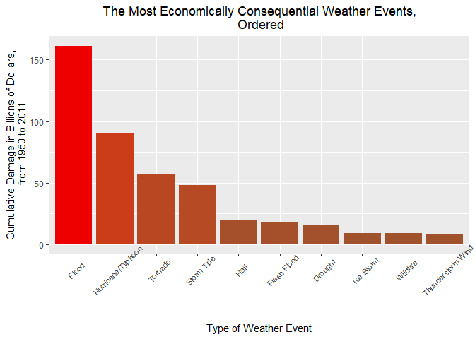

```r
neat10 <- summed_property_events_refined[1:10,]

ggplot(data = neat10) +
      geom_col(mapping = aes(x = fct_reorder(EVTYPE_MATCHED, TotalDamage, .desc = TRUE), y = TotalDamage/1000000000, fill = TotalDamage)) +
      theme(axis.text.x = element_text(angle = 45, size = 8, margin = margin(12))) +
      theme(plot.title = element_text(hjust = 0.5), plot.caption = element_text(hjust = 0.5))+
      scale_fill_gradient(low = "sienna", high = "red2")+
      theme(legend.position = "none")+
      labs(title = "The Most Economically Consequential Weather Events,\n Ordered", y = "Cumulative Damage in Billions of Dollars,\n from 1950 to 2011",
           x = "Type of Weather Event")
```

We can see clearly that the weather events that cause the most economic damage in the United States share some similarities with the weather events that cause the most impact on human health, but there is not a $1:1$ correspondence. In particular, we see that water and wind related events cause by far the most economic damage in the United States, while heat related events, which ranked highly in the causes of weather-related injuries and fatalities, rank fairly low in terms of economic consequence.

It is important to note, however, that being as this data set ends in 2011, it misses the effect of recent global-warming mediated wildfires that have caused so much havoc in the United States in the last $12$ years, particularly in California. It would be interesting to re-run this analysis using more recent data to see if Wildfires jumped up the rankings of economically-consequential weather events as a result.